# EDA

elaine05

9/4/2019

## Q1.

Have total emissions from PM2.5 decreased in the United States from 1999 to 2008? Using the base plotting system, make a plot showing the total PM2.5 emission from all sources for each of the years 1999, 2002, 2005, and 2008.

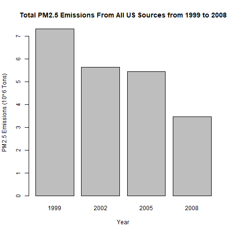

Yes, we can see from the trend, it’s decreasing.

## Q2.

Have total emissions from PM2.5 decreased in the Baltimore City, Maryland (fips==“24510”) from 1999 to 2008?

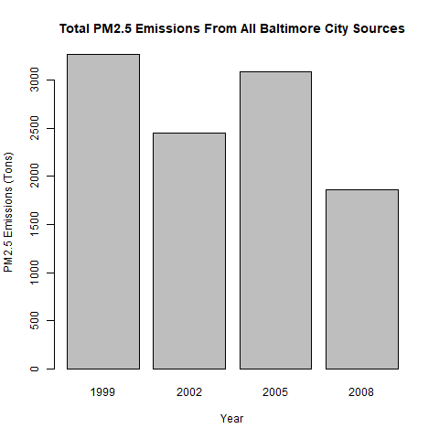

Yes, Overall total emissions from PM2.5 have decreased in Baltimore City, Maryland from 1999 to 2008.

## Q3.

Of the four types of sources indicated by the type (point, nonpoint, onroad, nonroad) variable, which of these four sources have seen decreases in emissions from 1999–2008 for Baltimore City? Which have seen increases in emissions from 1999–2008?

### Q3.1

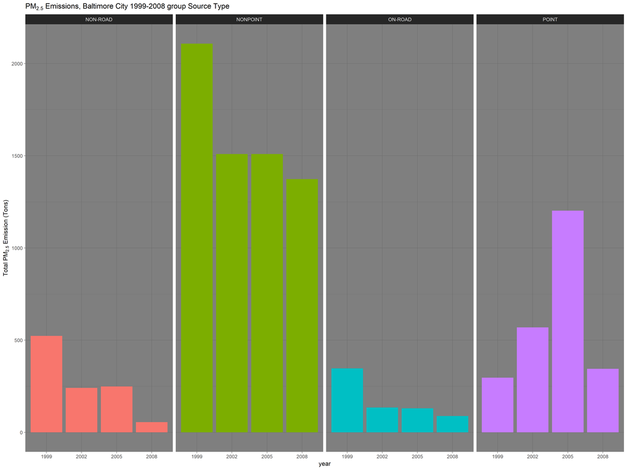

The non-road, nonpoint, on-road source types have all seen decreased emissions overall from 1999-2008 in Baltimore City.

## Q4.

Across the United States, how have emissions from coal combustion-related sources changed from 1999–2008?

[figure not shown]

Emissions from coal combustion related sources have decreased from 6 * 10^6 to below 4 * 10^6 from 1999-2008.

Eg. Emissions from coal combustion related sources have decreased by about 1/3 from 1999-2008!

## Q5.

How have emissions from motor vehicle sources changed from 1999–2008 in Baltimore City?

[figure not shown]

Emissions from motor vehicle sources have negative gradient(decreasing) from 1999-2008 in Baltimore City!

## Q6.

Compare emissions from motor vehicle sources in Baltimore City with emissions from motor vehicle sources in Los Angeles County, California (fips == “06037”). Which city has seen greater changes over time in motor vehicle emissions?

[figure not shown]

As from above graph,Los Angeles County has seen the greatest changes over time in motor vehicle emissions.